# 0011_which_patterns

Dan MacLean

2019-03-29

## Which bits of the expression profile is the classification coming from

The model can be used to tell us which parts of an expression profile are most useful in its classification. So we can use this to make a catalogue of all the expression profiles that it is classifying with. For each pair of expression profiles we need to extract the most useful parts.

The last convolutional layer of the model will be the one that has the useful stuff.

```r
arab_data <- readRDS("../data/scaled_arab_TF_one_channel.RDS")
keep <- arab_data$y == 1
positive_pairs <- arab_data$x[keep,,, ,drop = FALSE]
positive_pair_info <- arab_data$pair_info[keep,]

model <- load_model_hdf5("../data/convnet_model.hdf5")
#predictions <- model %>% predict(positive_pairs)
model
```

```
## Model
## ___________________________________________________________________________
## Layer (type)                     Output Shape                  Param #
## ===========================================================================
## separable_conv2d_1 (SeparableCon (None, 2, 232, 4)             18
## ___________________________________________________________________________
## max_pooling2d_1 (MaxPooling2D)   (None, 1, 116, 4)             0
## ___________________________________________________________________________
## separable_conv2d_2 (SeparableCon (None, 1, 116, 8)             80
## ___________________________________________________________________________
## batch_normalization_1 (BatchNorm (None, 1, 116, 8)             32
## ___________________________________________________________________________
## flatten_1 (Flatten)              (None, 928)                   0
## ___________________________________________________________________________
## dense_1 (Dense)                  (None, 8)                     7432
## ___________________________________________________________________________
## dropout_1 (Dropout)              (None, 8)                     0
## ___________________________________________________________________________
## dense_2 (Dense)                  (None, 1)                     9
## ===========================================================================
## Total params: 7,571
## Trainable params: 7,555
## Non-trainable params: 16
## ___________________________________________________________________________
```

So, `separable_conv2d_2`. Let’s code up a function to extract activations in the layer when an expression profile pair is passed through.

```r
get_class_activation_values <- function(expression_pair, model, layer = "separable_conv2d_2"){

  last_conv_layer <- model %>% get_layer(layer)
  real_interaction_output <- model$output[,1]
  grads <- k_gradients(real_interaction_output, last_conv_layer$output)[[1]]
  pooled_grads <- k_mean(grads, axis = c(1,2,3))

  iterate <- k_function(list(model$input),
                        list(pooled_grads, last_conv_layer$output[1,,,])
  )

  c(pooled_grads_value, conv_layer_output_value) %<-% iterate(list(expression_pair))

  for (i in 1:8){
    conv_layer_output_value[,,i] <- conv_layer_output_value[,,i] * pooled_grads_value[[i]]
  }

  activations <- apply(conv_layer_output_value, c(1,2), mean)
  return(activations)
}
```

Now run it for the first positive pair to get the activation levels. We should get a vector of activations of length 116, same as the final convnet layer.

```r
input_profile <- positive_pairs[1,,, , drop = FALSE]

act_levels <- get_class_activation_values(input_profile, model, layer = "separable_conv2d_2")

dim(act_levels)
```

```
## [1]   1 116
```

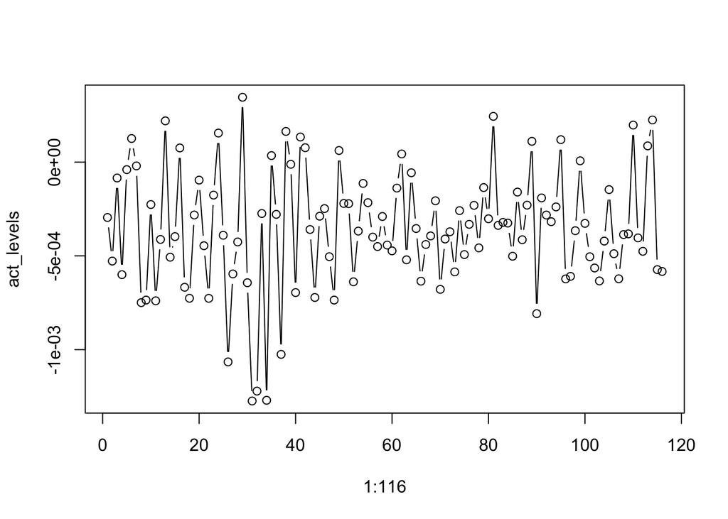

```r
plot(y= act_levels, x = 1:116, type = "b")
```

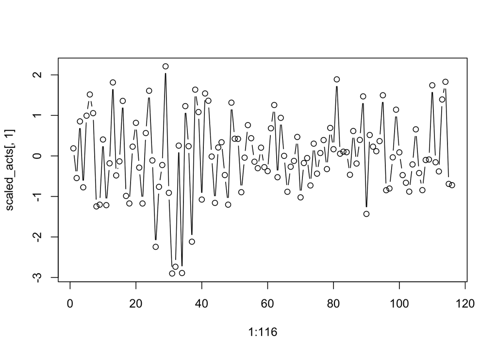

```r
#this scales around 0, so now all the largeest values are > 0
scaled_acts <-scale( act_levels[1,] )
plot(y= scaled_acts[,1], x = 1:116, type = "b")
```

Set anything less than 0 to 0.

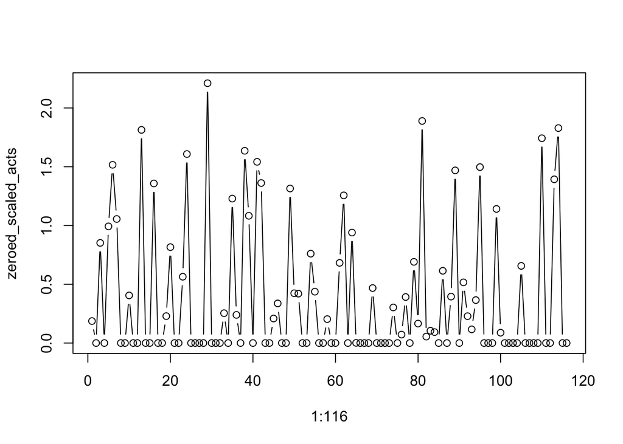

```r
zeroed_scaled_acts <- pmax(scaled_acts, 0)
plot(y= zeroed_scaled_acts, x = 1:116, type = "b")
```

Scale in range 0..1

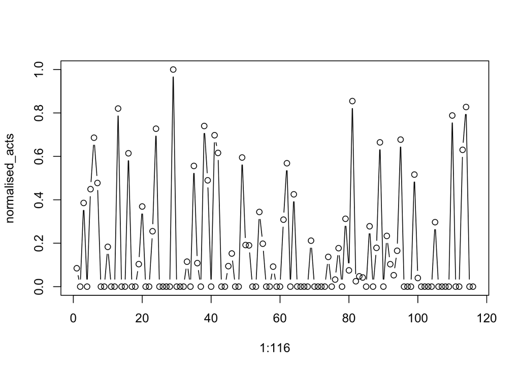

```r
normalised_acts <- zeroed_scaled_acts / max(zeroed_scaled_acts)
plot(y= normalised_acts, x = 1:116, type = "b")
```

Put in a function for later.

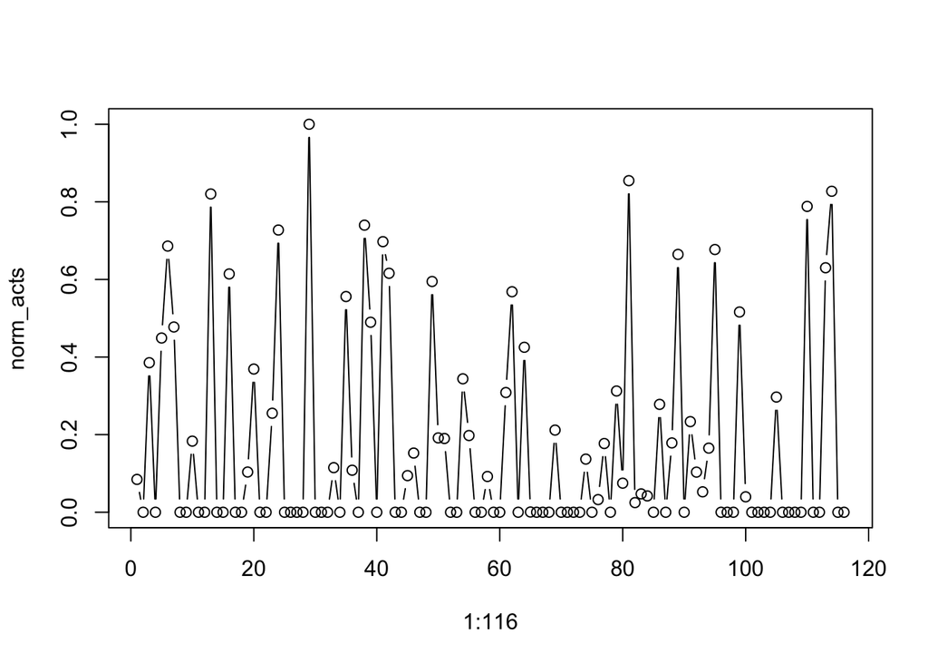

```r
normalise_activations <- function(acts){
  acts <- scale( acts[1,] ) #scale around 0
  acts <- pmax(acts, 0) #anything < 0 to 0
  return(acts / max(acts) ) #normalise 0..1
}

norm_acts <- normalise_activations(act_levels)
plot(y= norm_acts, x = 1:116, type = "b")
```

Now try smoothing, `spar = 0.4` is quite strong.

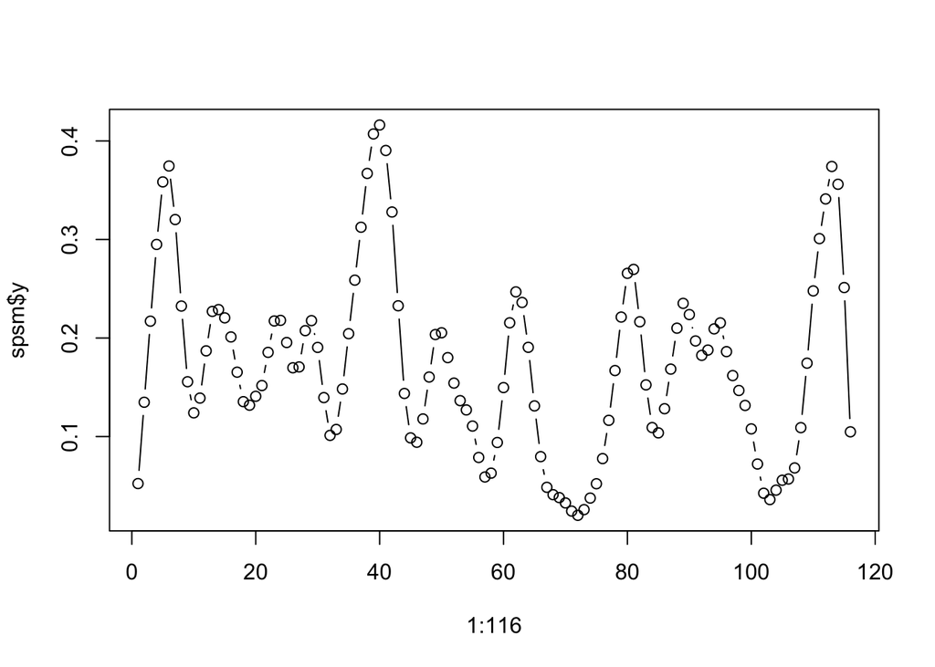

```r
spsm <- smooth.spline(norm_acts, spar = 0.4)
plot(y = spsm$y, x = 1:116, type = "b")
```

Now get peaks of activation.

```r
findPeaks(spsm$y)
```

```
##  [1]   7  15  25  30  41  51  63  82  90  96 114
```

```r
findValleys(spsm$y)
```

```
##  [1]  11  20  27  33  47  58  73  86  93 104
```

We now have a way to extract the highest activate region and thus the patterns from the expression dataset. I’ll build these into functions, put them in source file so I can extract patterns for all pairs.

```r
source("../scripts/utilities.R")
```

Here’s how we get an expression sub profile for one region

```r
peaks<- find_biggest_peak_indices(norm_acts)
peaks$start <- peaks$start * 2
peaks$end <- peaks$end * 2#because the convnet layer is half the width of the expression data

expression_data <- load_expression_file_as_matrix(file = "../lib/normalised_data.csv")

exprs <- get_expression_subprofile(expression_data,
                          positive_pair_info$TF[1],
                          positive_pair_info$Target[1],
                          peaks$start, peaks$end,
                          sub_only = TRUE)

exprs
```

```
##           GSM131321.CEL GSM131327.CEL GSM131330.CEL GSM131317.CEL
## 250476_at      5.389458      5.135043      4.778342      4.683745
## 264638_at      4.625345      5.032606      4.665783      4.418102
##           GSM131323.CEL GSM131312.CEL GSM131320.CEL GSM131309.CEL
## 250476_at      5.236138      5.357666      5.317203      5.009307
## 264638_at      6.338657      5.841628      4.934838      4.493584
##           GSM131326.CEL GSM131315.CEL GSM131318.CEL GSM131329.CEL
## 250476_at      5.050416      5.333819      4.866994      4.604172
## 264638_at      4.903150      5.097668      4.580333      4.620893
##           GSM131307.CEL GSM131310.CEL GSM131313.CEL GSM131295.CEL
## 250476_at      5.384214      5.143375      4.955610      5.188657
## 264638_at      6.251686      4.644150      4.740605      5.271864
##           GSM131292.CEL GSM131298.CEL GSM131304.CEL GSM131301.CEL
## 250476_at      5.150811      4.745853      5.304195      5.090361
## 264638_at      5.302124      4.838054      5.316085      4.833273
##           GSM131305.CEL GSM131284.CEL GSM131289.CEL GSM131287.CEL
## 250476_at      5.101885      5.502678      5.107605      5.384217
## 264638_at      4.918613      5.677872      4.894470      5.780755
##           GSM131290.CEL GSM131285.CEL GSM131296.CEL GSM131291.CEL
## 250476_at      4.957135      4.924237      5.244324      5.191496
## 264638_at      4.705869      4.541015      5.284372      5.362702
##           GSM131293.CEL GSM131299.CEL GSM131288.CEL GSM131294.CEL
## 250476_at      5.087401      5.409583      5.238950      5.069989
## 264638_at      4.783647      5.683506      5.717354      4.806750
##           GSM131302.CEL GSM131300.CEL GSM131297.CEL GSM131306.CEL
## 250476_at      5.428666      5.232272      5.197172      4.950211
## 264638_at      4.947096      6.736580      4.906808      4.852162
##           GSM131286.CEL GSM131283.CEL GSM131303.CEL GSM131268.CEL
## 250476_at      5.071661      5.248352      5.622777      5.184995
## 264638_at      4.820677      5.693002      5.652980      6.125636
##           GSM131263.CEL GSM131277.CEL GSM131265.CEL GSM131260.CEL
## 250476_at      5.339058      5.090541      4.804790      5.467914
## 264638_at      6.402671      4.651107      4.498421      5.839655
##           GSM131271.CEL
## 250476_at      5.253056
## 264638_at      5.765414
```

```r
peaks
```

```
## $start
## [1] 134
##
## $end
## [1] 178
##
## $smooth_curve
## Call:
## stats::smooth.spline(x = norm_acts, spar = spar)
##
## Smoothing Parameter  spar= 0.4  lambda= 3.003692e-06
## Equivalent Degrees of Freedom (Df): 28.3523
## Penalized Criterion (RSS): 7.606966
## GCV: 0.1148652
```

### Running extraction on input data.

Let’s try running the extraction on a few samples

```r
pp_list <- alply(positive_pairs,1)

back_to_4d <- function(x){ array(x, dim = c(1,2, 232, 1) ) }
pp_list <- lapply(pp_list, back_to_4d) #put the objects in the list back to the proper dim
regions <- NULL
if (! file.exists("../data/region_profiles.RDS") ){
  regions <- map2(pp_list, 1:4352,
                  .f = find_informative_expression_regions,
                  info = positive_pair_info,
                  expr_data = expression_data,
                  model = model)

} else {
  regions <- readRDS("../data/region_profiles.RDS")
}
```

Ok, lets check how many pairs we found peaks for. Quick correction - remove all width 0 peaks.

```r
reset_zero_width_peaks <- function(x){
  if(x$peaks$start == x$peaks$end){
    x$peaks$start <- x$peaks$end <- x$informative_region <- NA
  }
  return(x)
}
regions <-lapply(regions, reset_zero_width_peaks)

got_peak <- function(x){ length(x$informative_region) >= 2 }
sum(unlist(lapply(regions, got_peak)))
```

```
## [1] 4351
```

All but one of them!

To visualise them we’ll need to have them all the same length. And in one dimension. I’ll subtract the TF from the Target and pad to length and build a matrix. I’ll scale the resulting vector too, to iron out size differences

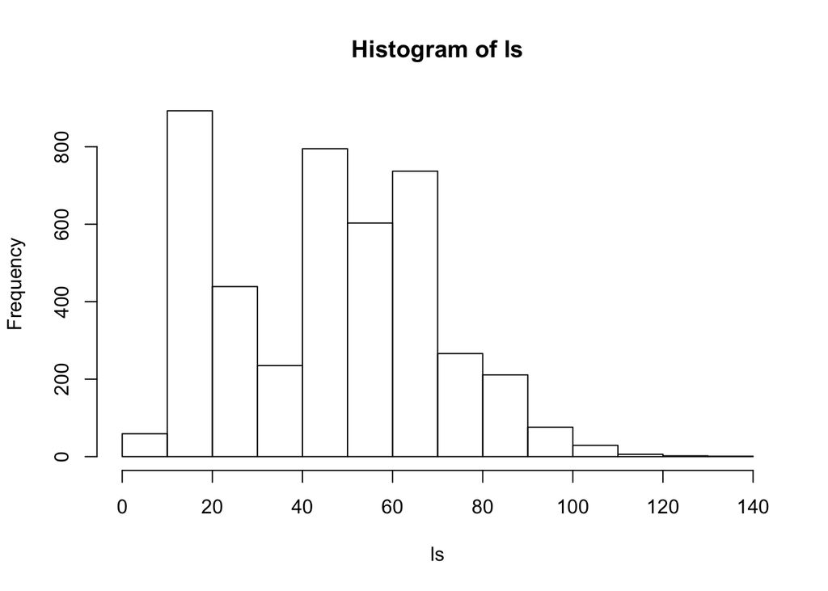

```r
ls <- unlist(lapply(regions, function(x){length(x$informative_region )}))
hist(ls)
```

```r
max_l <- max(ls)
normalise_expression_sub_profile <- function(x, ml = 138, smooth= FALSE){
  if( is.na(x$peaks$start) & is.na(x$peaks$end)){
    return(rep(0, ml))
  }
  else{
    sp <- scale(x$informative_region[2, ] - x$informative_region[1,])
    if (smooth & length(x$informative_region) >= 4) {

      sp <- tryCatch({
        return(c(
        smooth.spline(sp, spar = 0.4),
        rep(0, (ml - length(sp)))
              )
        )
      }
      , warning = function(w){
            return(c(sp, rep(0, (ml - length(sp)))))
      }, error = function(e){
            return(c(sp, rep(0, (ml - length(sp)))))
      })
    }
    return(c(sp, rep(0, (ml - length(sp)))))
  }

}

normalised_profiles <- lapply(regions, normalise_expression_sub_profile, ml = max_l)
```

```r
normalised_profiles[[1]]
```

```
##   [1] -1.669977215 -0.301982870 -0.322909787 -0.639406148  2.189225810
##   [6]  0.910378643 -0.880725217 -1.156438692 -0.394665419 -0.578432364
##  [11] -0.682860203 -0.055627448  1.703273521 -1.122329596 -0.534713674
##  [16]  0.081830269  0.222637285  0.100425081 -0.065615388 -0.621718954
##  [21] -0.469106693  0.272010502 -0.530847507  0.729632269 -0.609682152
##  [26] -0.882497037 -0.007399608  0.263765437 -0.718199443  0.476129608
##  [31]  0.898887652 -0.634435954 -1.085828438  3.019911947 -0.690516039
##  [36] -0.292910817 -0.609099126  0.829102318 -0.027753836  1.854548130
##  [41]  2.108788877 -0.998713581 -0.723605874  0.678365250  0.969086481
##  [46]  0.000000000  0.000000000  0.000000000  0.000000000  0.000000000
##  [51]  0.000000000  0.000000000  0.000000000  0.000000000  0.000000000
##  [56]  0.000000000  0.000000000  0.000000000  0.000000000  0.000000000
##  [61]  0.000000000  0.000000000  0.000000000  0.000000000  0.000000000
##  [66]  0.000000000  0.000000000  0.000000000  0.000000000  0.000000000
##  [71]  0.000000000  0.000000000  0.000000000  0.000000000  0.000000000
##  [76]  0.000000000  0.000000000  0.000000000  0.000000000  0.000000000
##  [81]  0.000000000  0.000000000  0.000000000  0.000000000  0.000000000
##  [86]  0.000000000  0.000000000  0.000000000  0.000000000  0.000000000
##  [91]  0.000000000  0.000000000  0.000000000  0.000000000  0.000000000
##  [96]  0.000000000  0.000000000  0.000000000  0.000000000  0.000000000
## [101]  0.000000000  0.000000000  0.000000000  0.000000000  0.000000000
## [106]  0.000000000  0.000000000  0.000000000  0.000000000  0.000000000
## [111]  0.000000000  0.000000000  0.000000000  0.000000000  0.000000000
## [116]  0.000000000  0.000000000  0.000000000  0.000000000  0.000000000
## [121]  0.000000000  0.000000000  0.000000000  0.000000000  0.000000000
## [126]  0.000000000  0.000000000  0.000000000  0.000000000  0.000000000
## [131]  0.000000000  0.000000000  0.000000000  0.000000000  0.000000000
## [136]  0.000000000  0.000000000  0.000000000
```

```r
ma <-t(matrix(unlist(normalised_profiles, use.names = FALSE), nrow = max_l))
head(ma)
```

```
##            [,1]       [,2]       [,3]       [,4]       [,5]       [,6]
## [1,] -1.6699772 -0.3019829 -0.3229098 -0.6394061  2.1892258  0.9103786
## [2,] -1.2071842  0.8830624  0.7068408 -0.9224952  0.8885279  0.8246320
## [3,]  0.4328552  0.6372846  0.6238776  0.2844125 -1.7185261  0.7524897
## [4,]  1.1429749 -1.0668991 -1.2188718  0.8895694  0.8452346 -0.8831904
## [5,]  0.0000000  0.0000000  0.0000000  0.0000000  0.0000000  0.0000000
## [6,]  0.6392976 -1.9100127 -0.5151122 -0.2799065  1.2252815 -0.4470832
##            [,7]       [,8]       [,9]      [,10]      [,11]       [,12]
## [1,] -0.8807252 -1.1564387 -0.3946654 -0.5784324 -0.6828602 -0.05562745
## [2,] -1.0977227 -1.1542607 -0.8464512  0.7986351 -1.1337350  0.94833047
## [3,] -1.6634636  0.6299279 -0.7927930  0.9898637  0.5559783 -1.38271077
## [4,]  0.9598987  0.9142876 -1.0122890 -1.0359318 -0.8935859  0.93361877
## [5,]  0.0000000  0.0000000  0.0000000  0.0000000  0.0000000  0.00000000
## [6,]  0.8878938 -0.6668272  0.7196999 -0.6845568  0.3899645  0.96418907
##           [,13]      [,14]      [,15]       [,16]      [,17]      [,18]
```

[output cut: 104 more lines]

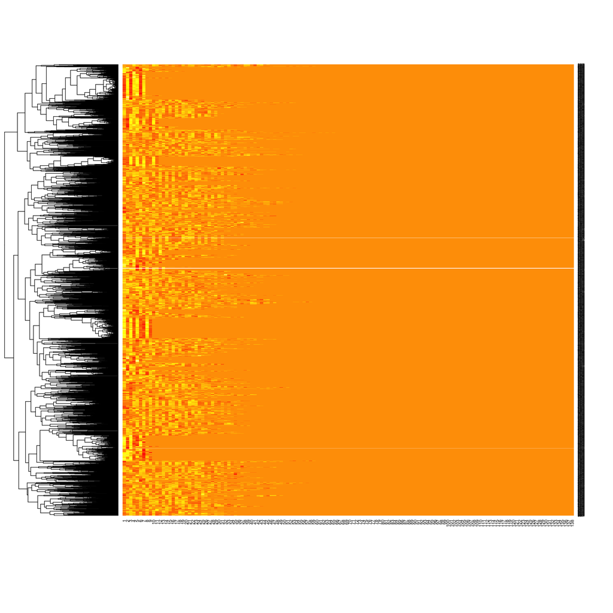

```r
heatmap(ma, na.rm = TRUE, Colv = NA)
```

There are some discernible patterns. They all seem to be ones that change rapidly, so very clear increases then decreases of one relative to the others. Not sure that subtracting one from the other is very helpful, though. Need a way to keep the information from the two rows of the expression profile.

Let’s try clustering and getting representative profiles from the clusters.

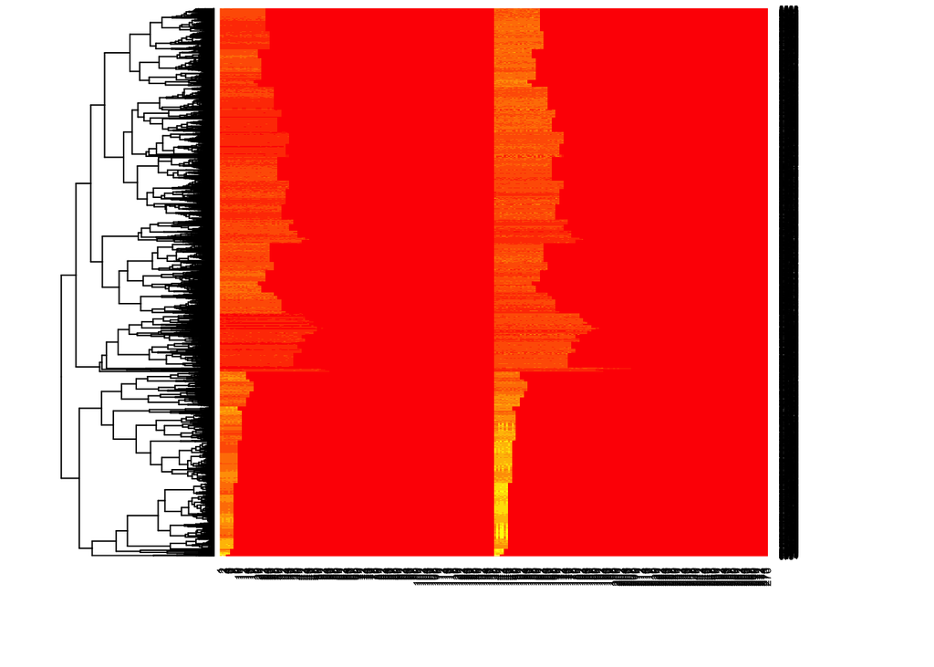

```r
linear_and_scale <- function(x, ml = 138){
    if( is.na(x$peaks$start) & is.na(x$peaks$end)){
    return(rep(0, ml))
  }
  scale(
    c( x$informative_region[1, ],
       rep(0, (ml  / 2 ) -  (length(x$informative_region[1,])) ),
       x$informative_region[2, ],
       rep(0, (ml / 2) -  (length(x$informative_region[1,]))  )
    )
  )

   # c(x$informative_region[1, ],
  #    x$informative_region[2,])) ,
  #  rep(0, (ml -  (length(x$informative_region[1,]) *2 ) ) )

}


padded_profiles <- lapply(regions,linear_and_scale, ml = max_l * 2)
#padded_profiles <- map2(regions, ll, linear_and_scale, ml = max_l * 2)

pma <-t(matrix(unlist(padded_profiles, use.names = FALSE), nrow = max_l * 2))
heatmap(pma, Colv = NA)
```

```r
dim(pma)
```

```
## [1] 4352  276
```

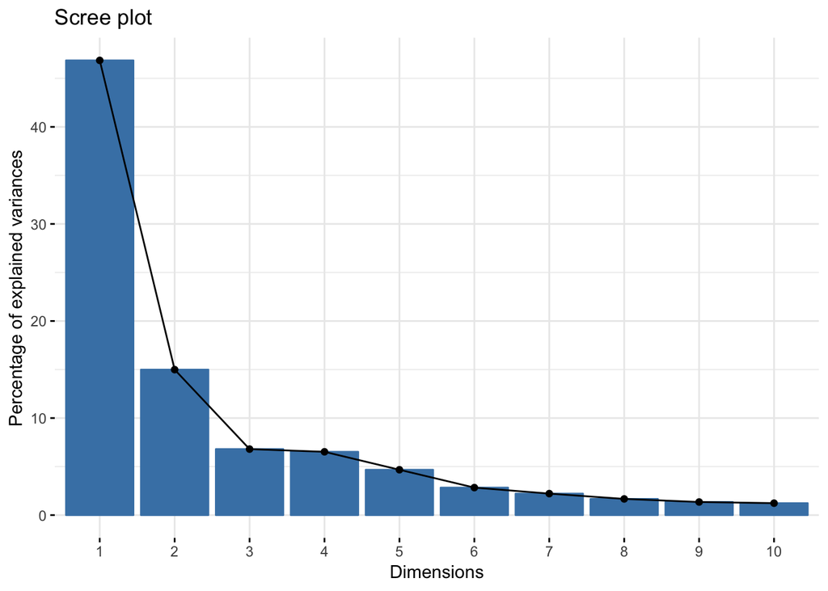

```r
pca_pma <- prcomp(pma, scale = FALSE)
fviz_eig(pca_pma)
```

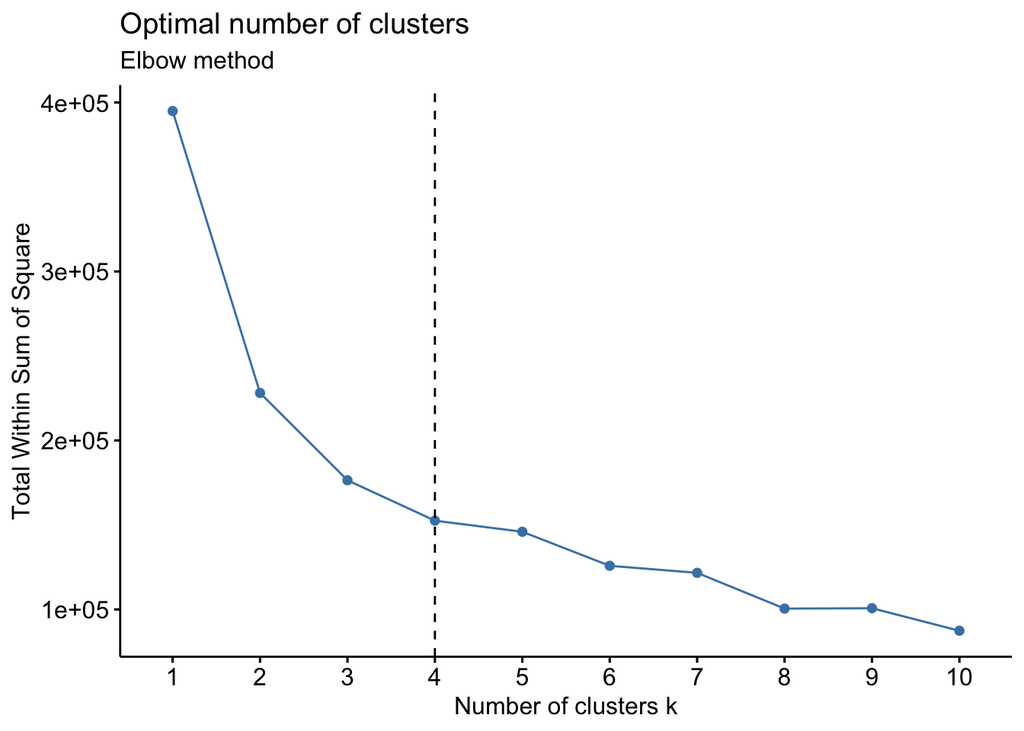

```r
saveRDS(pca_pma, "pca_cluster_estimate.RDS")
fviz_nbclust(pma, kmeans, method = "wss") +
    geom_vline(xintercept = 4, linetype = 2)+
  labs(subtitle = "Elbow method")
```

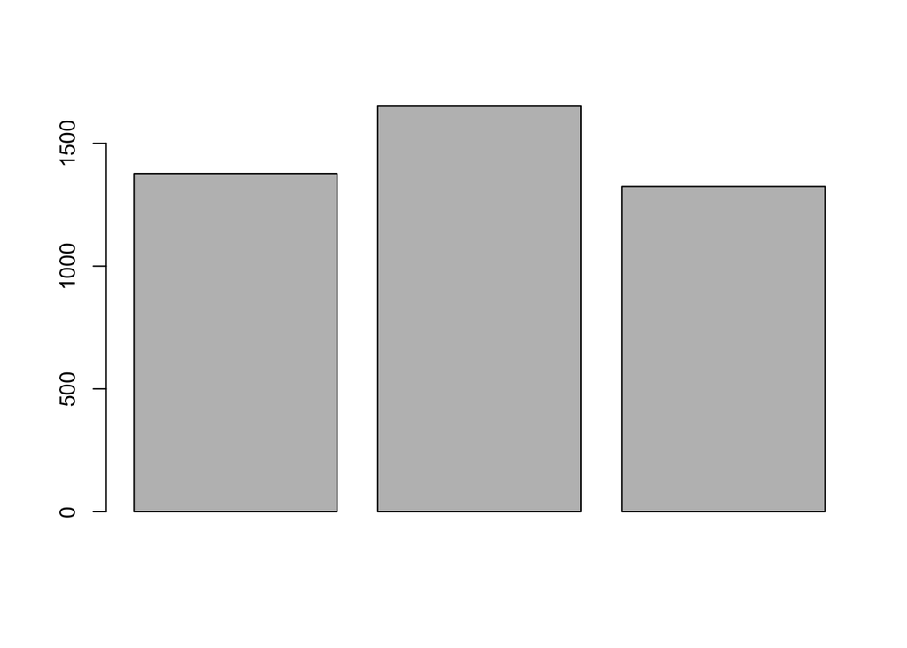

```r
nclus <- 3
kms <- kmeans(pma, nclus, nstart = 20)
barplot(kms$size)
```

```r
cluster_mean_profiles <- list()

for (i in 1:nclus){

  l <- length(kms$centers[i,])#sum( ! kms$centers[i,] == 0) # need to extract the tf target portion of the linearised profile

  cluster_mean_profiles[[i]] <- data.frame(
    cluster = rep(i, l),
    type = c(rep("TF", l / 2), rep("Target", l / 2)),
    value = kms$centers[i,1:l],
    position = c( seq(1:(l/2)), seq(1:(l/2)) )
    )
}
cluster_mean_profiles <- do.call("rbind", cluster_mean_profiles)
```

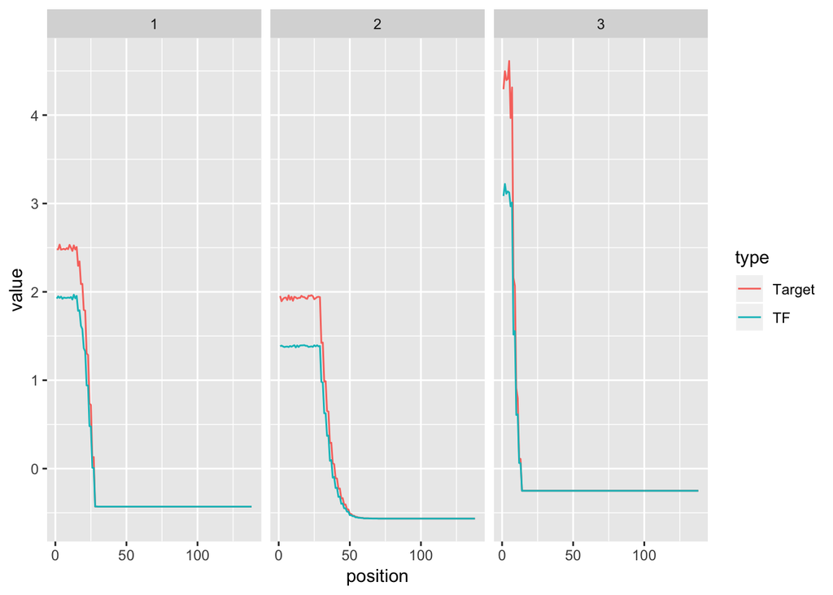

```r
ggplot(cluster_mean_profiles) + aes(position, value ) + geom_line(aes(colour = type) ) + facet_wrap(~ cluster, scales= "free_x")
```

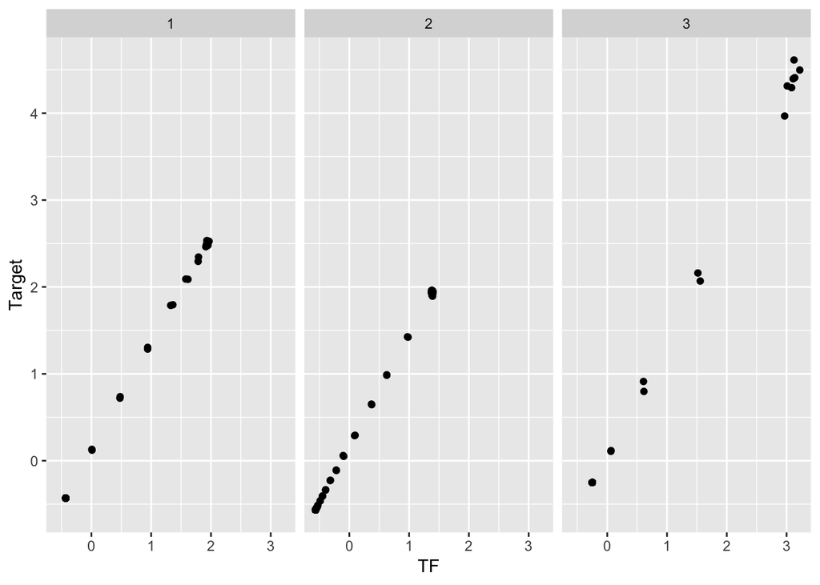

```r
cluster_mean_profiles %>%
 spread(type, value) %>%
  ggplot() + aes(TF, Target) + geom_point() + facet_wrap(~ cluster)
```

Some very clear patterns here. Basically these are positively correlated patterns of expression. So the expression relationships are ones where the TF transcript abundance mirrors the TF target abundance. The large curves at the RHS are caused by the padding of the clusters with zero. It may be informative to remove the padded parts. Also in earlier sections, perhaps there is a way to do sub clustering without so much padding.

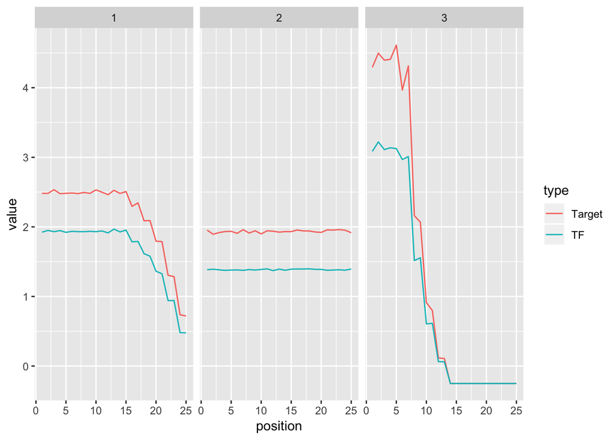

```r
cluster_mean_profiles %>%
  filter(position <= 25) %>%
ggplot + aes(position, value ) + geom_line(aes(colour = type) ) + facet_wrap(~ cluster, scales= "free_x")
```

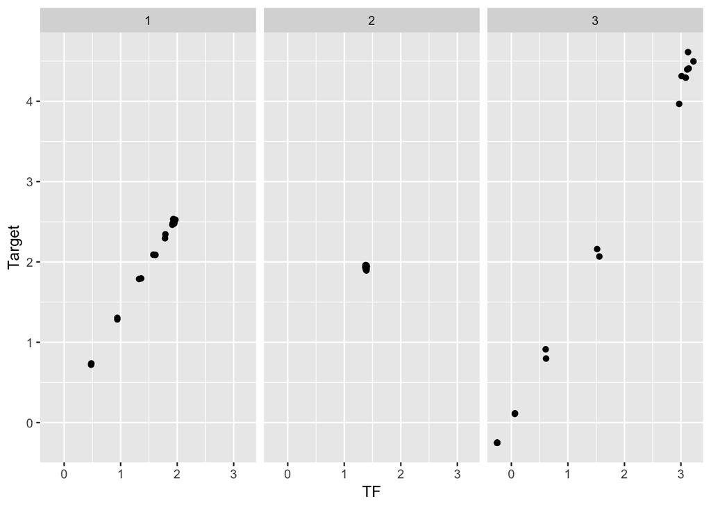

```r
cluster_mean_profiles %>%
 spread(type, value) %>%
    filter(position <= 25) %>%
  ggplot() + aes(TF, Target) + geom_point() + facet_wrap(~ cluster)
```

```r
saveRDS(cluster_mean_profiles, "cluster_mean_profiles.RDS")
```

```
position = expression value position in the expression value file,
value = expression estimate
TF on x axi really means TF expression estimate
Target on y axis really means Target expression estimate
```